# Peer-graded Assignment: Course Project 1

```r
library(knitr)
opts_chunk$set(echo= FALSE)
```

# Loading and preprocessing the data

```
## 'data.frame':    17568 obs. of  3 variables:
##  $ steps   : int  NA NA NA NA NA NA NA NA NA NA ...
##  $ date    : chr  "2012-10-01" "2012-10-01" "2012-10-01" "2012-10-01" ...
##  $ interval: int  0 5 10 15 20 25 30 35 40 45 ...
```

# What is mean total number of steps taken per day?

## Calculate the total number of steps taken per day

| Date | Steps |
| --- | --- |
| 2012-10-01 | 0 |
| 2012-10-02 | 126 |
| 2012-10-03 | 11352 |
| 2012-10-04 | 12116 |
| 2012-10-05 | 13294 |
| 2012-10-06 | 15420 |
| 2012-10-07 | 11015 |
| 2012-10-08 | 0 |
| 2012-10-09 | 12811 |
| 2012-10-10 | 9900 |

[output cut: 51 more lines]

## Make a histogram of the total number of steps taken each day

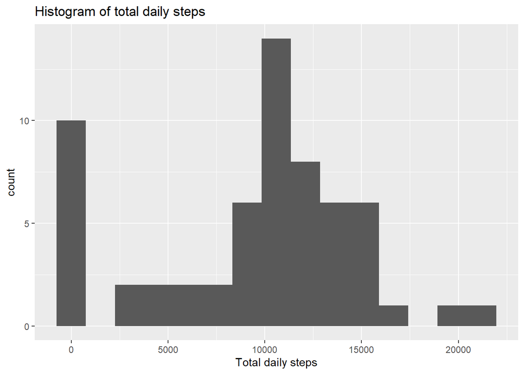

## Calculate and report the mean and median of the total number of steps taken per day

```
##    Min. 1st Qu.  Median    Mean 3rd Qu.    Max.
##       0    6778   10395    9354   12811   21194
```

# What is the average daily activity pattern?

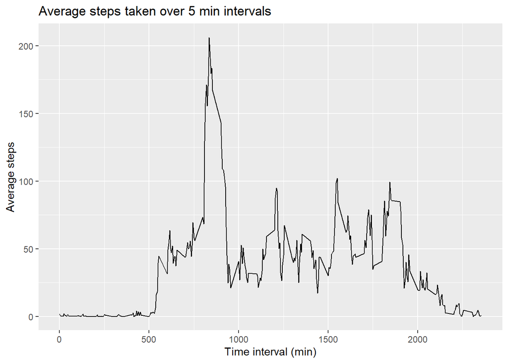

#Which 5-minute interval contains the maximum number of steps?

```
## [1] 835
```

The 835 min interval contains the maximum number of steps

# Imputing missing values

## Calculate and report the total number of missing values in the dataset

```
## [1] 2304
```

## Create a new dataset with the missing data filled in.

## Make a histogram of the total number of steps taken each day

[figure not shown]

## Calculate and report the mean and median total number of steps taken per day

| Date | Steps |
| --- | --- |
| 2012-10-01 | 10909 |
| 2012-10-02 | 126 |
| 2012-10-03 | 11352 |
| 2012-10-04 | 12116 |
| 2012-10-05 | 13294 |
| 2012-10-06 | 15420 |
| 2012-10-07 | 11015 |
| 2012-10-08 | 10909 |
| 2012-10-09 | 12811 |
| 2012-10-10 | 9900 |

[output cut: 51 more lines]

```
##    Min. 1st Qu.  Median    Mean 3rd Qu.    Max.
##      41    9819   10909   10785   12811   21194
```

The new mean daily steps is 10,785 and the new median is 10,909. Both the mean and the median increased in value and got closer to each other.

# Are there differences in activity patterns between weekdays and weekends?

## Create a new factor variable indicating whether a given date is a weekday or weekend day.

## time series plot of the 5-minute interval (x-axis) and the average number of steps taken by day type

[figure not shown]